# Collage Admission

*By: Amani Alghamdi*

In this project we will go through different analysis starting from univarite to bivariate for feature selection also we will try one other alternative method like backward elimination. Also we will be cleaning the data and dealing with missing values and outliers. After finishing from descriptive analysis. we will be going through Machine learing techniques using different models, because our case is classification therefore we will use logistic regression, SVM and decision tree. Moreover, the last step is evaluating models and accuracy to choose the best model for prediction.

```r
## load packages
library(plyr)       # used for apply fun
library(dplyr)      # used for data manipulation and joining
library(ggplot2)    # used for ploting
library(e1071)      # used for Machine Learning SVM
library(caret)      # used for
library(rpart)      # used for decision trees
library(ggplot2)    # used for plots
library(caTools)    # used for sampling
library(rpart.plot) # used for tree plot
library(Metrics)
```

```r
## read datasets
MyData = read.csv("C:/Users/gorea/Downloads/R-demos/college_admission/College_admission.csv")
```

```r
## structure of the dataframe
str(MyData)
```

```
'data.frame':   400 obs. of  7 variables:
 $ admit      : int  0 1 1 1 0 1 1 0 1 0 ...
 $ gre        : int  380 660 800 640 520 760 560 400 540 700 ...
 $ gpa        : num  3.61 3.67 4 3.19 2.93 3 2.98 3.08 3.39 3.92 ...
 $ ses        : int  1 2 2 1 3 2 2 2 1 1 ...
 $ Gender_Male: int  0 0 0 1 1 1 1 0 1 0 ...
 $ Race       : int  3 2 2 2 2 1 2 2 1 2 ...
 $ rank       : int  3 3 1 4 4 2 1 2 3 2 ...
```

We can clearly see that we have 400 observations and 7 variables. Note that only GPA is a numaric variable and the rest are integers. GRE and GPA are continuous data whereas, the rest are categorical,therefore we are going to transform them to factors later on.

```r
## Columns names
names(MyData)
```

```
[1] "admit"       "gre"         "gpa"         "ses"         "Gender_Male"
[6] "Race"        "rank"
```

```r
# Summary of the dataset
summary(MyData)
```

```
     admit             gre             gpa             ses         Gender_Male
 Min.   :0.0000   Min.   :220.0   Min.   :2.260   Min.   :1.000   Min.   :0.000
 1st Qu.:0.0000   1st Qu.:520.0   1st Qu.:3.130   1st Qu.:1.000   1st Qu.:0.000
 Median :0.0000   Median :580.0   Median :3.395   Median :2.000   Median :0.000
 Mean   :0.3175   Mean   :587.7   Mean   :3.390   Mean   :1.992   Mean   :0.475
 3rd Qu.:1.0000   3rd Qu.:660.0   3rd Qu.:3.670   3rd Qu.:3.000   3rd Qu.:1.000
 Max.   :1.0000   Max.   :800.0   Max.   :4.000   Max.   :3.000   Max.   :1.000
      Race            rank
 Min.   :1.000   Min.   :1.000
 1st Qu.:1.000   1st Qu.:2.000
 Median :2.000   Median :2.000
 Mean   :1.962   Mean   :2.485
 3rd Qu.:3.000   3rd Qu.:3.000
 Max.   :3.000   Max.   :4.000
```

From the table above we can highlight the central tendency measures for all variables. now let depicts those variables to see their distributions.

```r
# Change admit to factor
MyData$admit <- factor(MyData$admit)
# Change rank to factor
MyData$rank <- factor(MyData$rank)
# Change gender to factor
MyData$Gender_Male <- factor(MyData$Gender_Male)
# Change gender to factor
MyData$ses <- factor(MyData$ses)
# Change gender to factor
MyData$Race <- factor(MyData$Race)
str(MyData)
```

```
'data.frame':   400 obs. of  7 variables:
 $ admit      : Factor w/ 2 levels "0","1": 1 2 2 2 1 2 2 1 2 1 ...
 $ gre        : int  380 660 800 640 520 760 560 400 540 700 ...
 $ gpa        : num  3.61 3.67 4 3.19 2.93 3 2.98 3.08 3.39 3.92 ...
 $ ses        : Factor w/ 3 levels "1","2","3": 1 2 2 1 3 2 2 2 1 1 ...
 $ Gender_Male: Factor w/ 2 levels "0","1": 1 1 1 2 2 2 2 1 2 1 ...
 $ Race       : Factor w/ 3 levels "1","2","3": 3 2 2 2 2 1 2 2 1 2 ...
 $ rank       : Factor w/ 4 levels "1","2","3","4": 3 3 1 4 4 2 1 2 3 2 ...
```

we have sucsessfully changed categorical variables to factors

## Univariate Analysis

### GRE Distribution

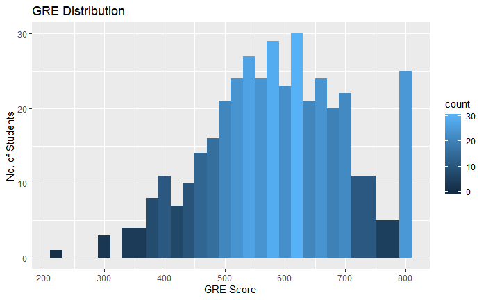

```r
#GRE
# DATA & AESTHETICS
gre_pl <- ggplot(MyData,aes(gre))
# GEOMETRY
print( gre_pl + geom_histogram(binwidth = 20,aes(fill=..count..)) + xlab("GRE Score")+ ylab("No. of Students")+ ggtitle("GRE Distribution")+ scale_x_continuous(breaks=seq(min(200),max(800),by=100)))
```

From the above graph we conclude that the majority of the students gre scores around their mean score. and there is exsistance of outliers in the lower limits.The maximum value is 800 and it has a high frequency and the lowest is 220 with very low frequincy.

### GPA Distribution

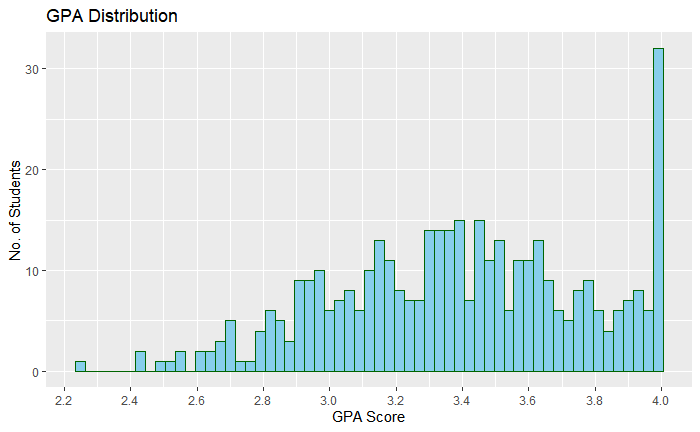

```r
# DATA & AESTHETICS
gpa_pl <- ggplot(MyData,aes(gpa))
# GEOMETRY
print(gpa_pl + geom_histogram(binwidth = 0.03,color="darkgreen",fill="skyblue") + xlab("GPA Score")+ ylab("No. of Students")+ ggtitle("GPA Distribution")+ scale_x_continuous(breaks=seq(min(2),max(4),by=0.2)))
```

GPA distribution depicts that the majority of students gpa scores around their mean and there is a significant raise in the students gpa that have 4 points , also there is gpa outliers noticed. The highest gpa frequency is recorded for the maximum gpa score of 4, whearase the lowest gpa of 2.26 has the lowest frequency.

#### Admission Distribution

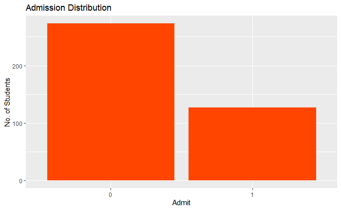

```r
# DATA & AESTHETICS
pl <- ggplot(MyData,aes(x=admit))
# GEOMETRY
print(pl + geom_bar(fill="orangered") +xlab("Admit")+ ylab("No. of Students")+ ggtitle("Admission Distribution "))
```

The above graph shows an overall low frequencies in admissions comparing to the students who didn’t admitted by almost half ratio.

### Bivariate Analysis:

##### Categorical & Categorical (Chi-square)

### Gender and Admission

```r
# contengency table
gender_admit_tab<- table(MyData$Gender_Male,MyData$admit)
gender_admit_tab
```

```
      0   1
  0 141  69
  1 132  58
```

Males are 1 wherease female is 0  
Admitted is 1 whereas not admitted is 0  
so we can see that there is no significant difference among men and women that have been admitted or not admitted.  
Now lets conduct a chi_square test to check weather the gender affects the admission of student or not.  
*First we need to set the hypothesis:*  
**H0: admission is independent of gender**  
**Ha: admission is related to gender**  
**We’ll set a = 0.05**

```r
# Chi-square test
chisq.test(gender_admit_tab)
```

```
    Pearson's Chi-squared test with Yates' continuity correction

data:  gender_admit_tab
X-squared = 0.15409, df = 1, p-value = 0.6947
```

we can conclude to p > 0.05 which is mean that we fail to reject the null hypothesis, therefore theres is no relation between admission and gender.

### Gender and Admission

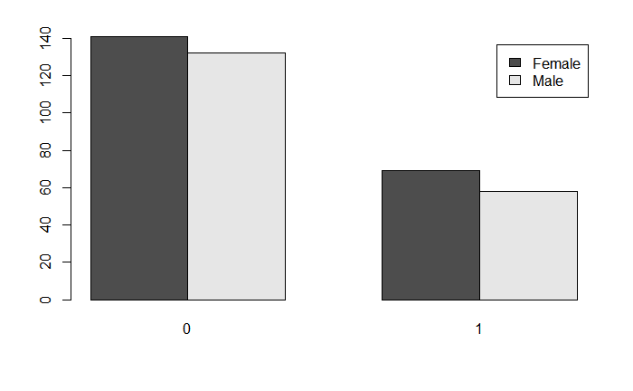

```r
barplot(gender_admit_tab,beside = T,legend.text =c('Female','Male'))
```

The plot confirms what we have declared so far that there is no significant difference between male and female admission, therefore admission and gender are independent variables.

### Rank and Admission

```r
# contengency table
rank_admit_tab<- table(MyData$rank,MyData$admit)
# Chi-square test
chisq.test(rank_admit_tab)
```

```
    Pearson's Chi-squared test

data:  rank_admit_tab
X-squared = 25.242, df = 3, p-value = 1.374e-05
```

at alpha of 0.05 p < 0.05, therefore we can reject the null hypothesis thus there is a relationship between rank and admission

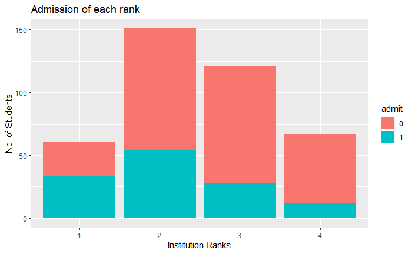

```r
# DATA & AESTHETICS
pl <- ggplot(MyData,aes(x=rank))
# GEOMETRY
print(pl + geom_bar(aes(fill=admit)) +xlab("Institution Ranks")+ ylab("No. of Students")+ ggtitle("Admission of each rank "))
```

From the previous graph we find out that the maximum number of students who has addmitted was from 2 rank institutions in contrast, there is a considerable amount of unadmitted students in the same rank, likewise the rates keeps declining for the lower ranks. obviously the rank 1 has an equal portions of students who has admitted or not but its still has an overall low values.

### Race and Admission

```r
# contengency table
race_admit_tab<- table(MyData$Race,MyData$admit)
# Chi-square test
chisq.test(race_admit_tab)
```

```
    Pearson's Chi-squared test

data:  race_admit_tab
X-squared = 3.2294, df = 2, p-value = 0.1989
```

p > 0.05, therefore we cannot reject the null hypothesis. race has no effect to admession.

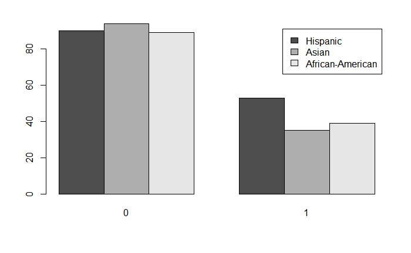

```r
barplot(race_admit_tab,beside = T,legend.text =c("Hispanic","Asian","African-American"))
```

### Socioeconomic and Admission

```r
# contengency table
ses_admit_tab<- table(MyData$ses,MyData$admit)
# Chi-square test
chisq.test(ses_admit_tab)
```

```
    Pearson's Chi-squared test

data:  ses_admit_tab
X-squared = 0.94031, df = 2, p-value = 0.6249
```

Socioeconomic and admission are independent variables.

#### Continuous & Categorical (ANOVA)

### GPA and Admission

```r
gpa_anova <- aov(MyData$gpa ~ MyData$admit)
gpa_anova
```

```
Call:
   aov(formula = MyData$gpa ~ MyData$admit)

Terms:
                MyData$admit Residuals
Sum of Squares       1.83531  55.95228
Deg. of Freedom            1       398

Residual standard error: 0.3749448
Estimated effects may be unbalanced
```

```r
summary(gpa_anova)
```

```
              Df Sum Sq Mean Sq F value   Pr(>F)
MyData$admit   1   1.84  1.8353   13.05 0.000341 ***
Residuals    398  55.95  0.1406
---
Signif. codes:  0 ‘***’ 0.001 ‘**’ 0.01 ‘*’ 0.05 ‘.’ 0.1 ‘ ’ 1
```

```r
gpa_anova$coefficients
```

```
  (Intercept) MyData$admit1
     3.343700      0.145513
```

we can conclude that we can reject the null hypothesis and there is a relationship between gpa and admission.

```r
TukeyHSD(gpa_anova)
```

```
  Tukey multiple comparisons of means
    95% family-wise confidence level

Fit: aov(formula = MyData$gpa ~ MyData$admit)

$`MyData$admit`
        diff        lwr       upr     p adj
1-0 0.145513 0.06633853 0.2246874 0.0003412
```

After doing different feature selecting techniques, we have find out some variables that infulence admission such as rank, gpa.

Now we have to do some cleaning like dealing with missing values and outliers.

### Missig Values

```r
# check weather there is a null values or not
any(is.na(MyData))
```

```
[1] FALSE
```

From this result we find out that there is no missing values thus, no treatment needed

### Outliers

So for applying the outliers treatment, we need to do 4 steps:

1. plot the dataset using boxplot to recognize the outliers.
2. display those outliers values
3. expose the rows where those outliers coming from
4. remove the rows where it contains the outliers, and depict the final boxplot with cleaned data with no outliers.

Discover the outliers by visuallization

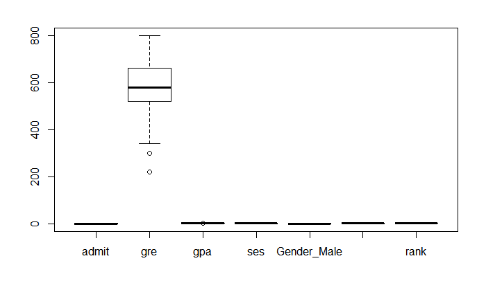

```r
# visuallize the data to have a clear observasions about the outliers
boxplot(MyData)
```

From the above plot we find existance of outliers in gre and gpa, but gpa outliers are not clear for a high notable variability in gre. therefore we ll try to make a separate plot for each one.

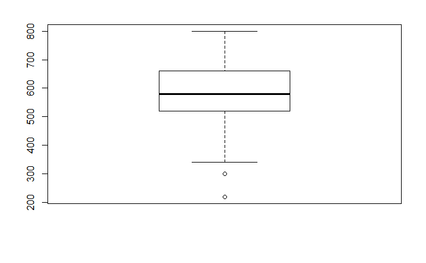

```r
# visuallize outliers using boxplot
outliers <- boxplot(MyData$gre)$out
```

```r
# display outliers values
print(outliers)
```

```
[1] 300 300 220 300
```

The above plot shows two points between 300 to 200

```r
# find in which rows the outliers are
MyData[which(MyData$gre %in% outliers),]
```

|  | admit | gre | gpa | ses | Gender_Male | Race | rank |
| --- | --- | --- | --- | --- | --- | --- | --- |
| 72 | 0 | 300 | 2.92 | 1 | 1 | 1 | 4 |
| 180 | 0 | 300 | 3.01 | 2 | 0 | 1 | 3 |
| 305 | 0 | 220 | 2.83 | 1 | 1 | 3 | 3 |
| 316 | 1 | 300 | 2.84 | 3 | 1 | 1 | 2 |

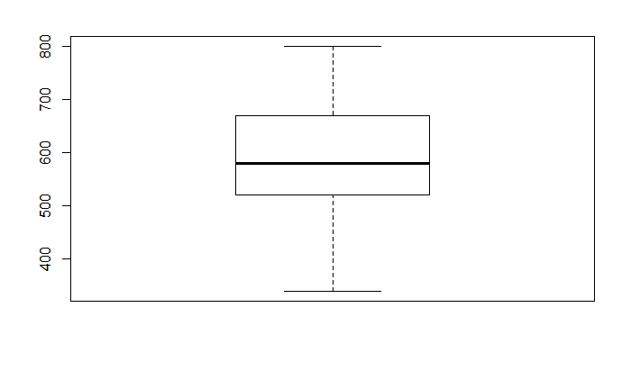

```r
# Now you can remove the rows containing the outliers:
MyData <- MyData[-which(MyData$gre %in% outliers),]
# checking the boxplot,  notice that those outliers are gone now (gre outliers are cleared)
clr_gre <- MyData$gre
boxplot(clr_gre)
```

Now repeat the process again to clean the gpa outliers.

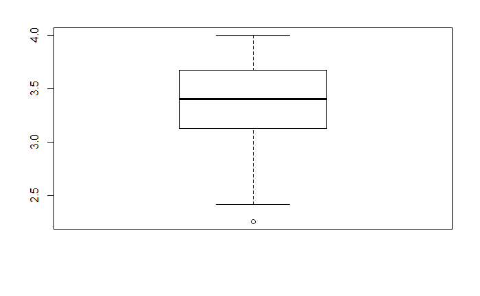

```r
# visuallize outliers using boxplot
outliers_gpa <- boxplot(MyData$gpa)$out
```

```r
# display outliers values
print(outliers_gpa)
```

```
[1] 2.26
```

We can see outliers are appears around 2

```r
# find in which rows the outliers are
MyData[which(MyData$gpa %in% outliers_gpa),]
```

|  | admit | gre | gpa | ses | Gender_Male | Race | rank |
| --- | --- | --- | --- | --- | --- | --- | --- |
| 290 | 0 | 420 | 2.26 | 2 | 1 | 2 | 4 |

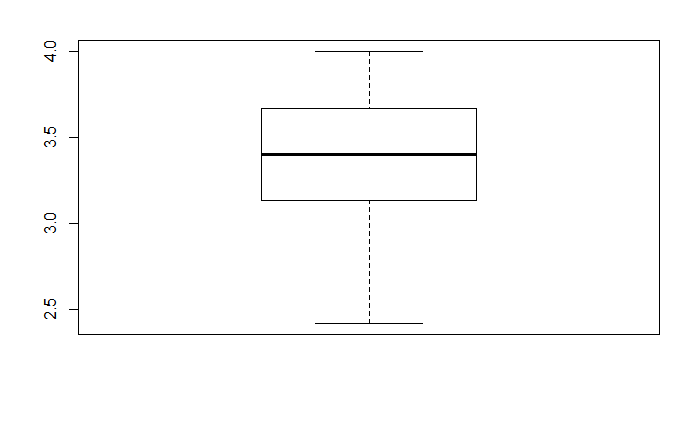

```r
# Now you can remove the rows containing the outliers:
MyData <- MyData[-which(MyData$gpa %in% outliers_gpa),]
# checking the boxplot,  notice that those outliers are gone now (gre outliers are cleared)
clr_gpa <- MyData$gpa
boxplot(clr_gpa)
```

### Transform GRE to factor

```r
# transform numeric to categorical
MyData$gre <- cut(MyData$gre, breaks = c(0,440,580,1000), labels = c("Low","Medium","High"), right = FALSE)
```

```r
head(MyData)
```

|  | admit | gre | gpa | ses | Gender_Male | Race | rank |
| --- | --- | --- | --- | --- | --- | --- | --- |
| 1 | 0 | Low | 3.61 | 1 | 0 | 3 | 3 |
| 2 | 1 | High | 3.67 | 2 | 0 | 2 | 3 |
| 3 | 1 | High | 4.00 | 2 | 0 | 2 | 1 |
| 4 | 1 | High | 3.19 | 1 | 1 | 2 | 4 |
| 5 | 0 | Medium | 2.93 | 3 | 1 | 2 | 4 |
| 6 | 1 | High | 3.00 | 2 | 1 | 1 | 2 |

Now our data is cleaned, now we need to normalize it

```r
norm_data <- MyData
norm_data[,3] <- scale(MyData[,3])
summary(norm_data)
```

```
 admit       gre             gpa.V1        ses     Gender_Male Race    rank
 0:269   Low   : 33   Min.   :-2.6049195   1:130   0:209       1:140   1: 61
 1:126   Medium:136   1st Qu.:-0.6999625   2:137   1:186       2:128   2:150
         High  :226   Median : 0.0060705   3:128               3:127   3:119
                      Mean   : 0.0000000                               4: 65
                      3rd Qu.: 0.7254249
                      Max.   : 1.6046358
```

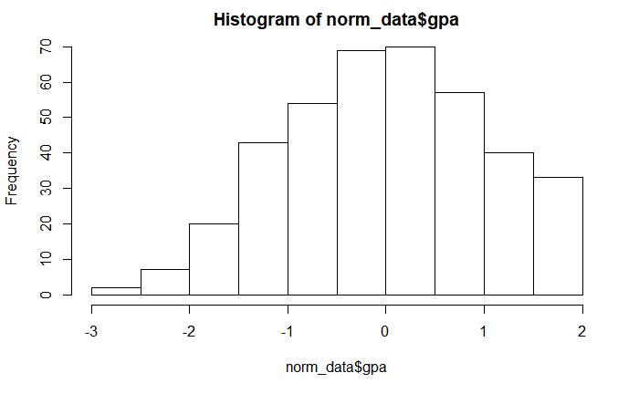

```r
# plot the normalized data using hist
hist(norm_data$gpa)
```

#### Machine learning steps:

1. SPLIT
2. APPLY MODEl
3. TEST
4. CHECK ACCURACY

```r
# split dataset

my_sample <- sample.split(norm_data, SplitRatio = 0.8)
my_sample
```

```
[1] FALSE FALSE  TRUE  TRUE  TRUE  TRUE  TRUE
```

```r
train <- subset(norm_data, my_sample==T)
test <- subset(norm_data, my_sample == F)
```

Logistic Regression

```r
#train the model using training data *** indicate statistical significance variables
#use glm the linear model function
#dependent variable is admit and independent variables are rank and gpa
#the family argument should be binomial to indicate logistic regression
log_model <- glm(admit ~ gpa+rank ,data = train,family = "binomial")
summary(log_model)
```

```
Call:
glm(formula = admit ~ gpa + rank, family = "binomial", data = train)

Deviance Residuals:
    Min       1Q   Median       3Q      Max
-1.5238  -0.9043  -0.6209   1.1353   2.1126

Coefficients:
            Estimate Std. Error z value Pr(>|z|)
(Intercept)  0.07093    0.30728   0.231 0.817445
gpa          0.44516    0.14316   3.109 0.001875 **
rank2       -0.68532    0.37162  -1.844 0.065165 .
rank3       -1.33756    0.40386  -3.312 0.000926 ***
rank4       -1.68825    0.49600  -3.404 0.000665 ***
---
Signif. codes:  0 ‘***’ 0.001 ‘**’ 0.01 ‘*’ 0.05 ‘.’ 0.1 ‘ ’ 1

(Dispersion parameter for binomial family taken to be 1)

    Null deviance: 350.90  on 280  degrees of freedom
Residual deviance: 321.74  on 276  degrees of freedom
AIC: 331.74

Number of Fisher Scoring iterations: 4
```

only important features are rank and gpa

```r
#test model data
t <- predict(log_model,test,type="response")
t
```

```
         1          2          8          9         15         16         22
0.26602818 0.28015210 0.27067181 0.21826728 0.68680908 0.22855446 0.41607514
        23         29         30         36         37         43         44
0.09091506 0.30466644 0.48579633 0.26370548 0.47395591 0.28736925 0.20251097
        50         51         57         58         64         65         71
0.21028086 0.32775341 0.18049517 0.14069845 0.32514560 0.36532607 0.36532607
        73         79         80         86         87         93         94
0.16431283 0.43574399 0.68680908 0.24790470 0.33035669 0.49532980 0.23701416
       100        101        107        108        114        115        121
0.20251097 0.17358394 0.56547070 0.28253620 0.46509405 0.32254858 0.44807677
       122        128        129        135        136        142        143
0.18580768 0.22945774 0.29718169 0.24133044 0.25686842 0.18659331 0.27404974
       149        150        156        157        163        164        170
0.37577575 0.49172336 0.09491285 0.16038217 0.39605555 0.19681461 0.26835038
       171        177        178        185        186        192        193
0.24352124 0.17700307 0.18761909 0.08801683 0.40745725 0.25013551 0.30217425
       199        200        206        207        213        214        220
0.27068538 0.23580910 0.31227071 0.55963349 0.22438713 0.21625038 0.40459695
       221        227        228        234        235        241        242
0.19682548 0.40174311 0.11251459 0.10624100 0.55670858 0.20249987 0.63642935
       248        249        255        256        262        263        269
0.29225129 0.27303312 0.18659331 0.21028086 0.28736925 0.18049517 0.36806439
       270        276        277        283        284        291        292
0.12306897 0.24790470 0.30468100 0.17431907 0.12234296 0.36531013 0.20635760
       298        299        306        307        313        314        321
0.26833689 0.37916618 0.17603273 0.45037585 0.30468100 0.21113169 0.17188915
       322        328        329        335        336        342        343
0.40174311 0.37359864 0.33562509 0.27303312 0.60856825 0.10400961 0.27641560
       349        350        356        357        363        364        370
0.34093473 0.22028590 0.34839107 0.31737249 0.28494656 0.36256466 0.49236521
       371        377        378        384        385        391        392
0.45689134 0.41607514 0.52495937 0.68680908 0.17700307 0.26370548 0.48940115
       398        399
0.17873740 0.42184939
```

```r
# confiusion matrix
confusionMatrix <- table(Actual_Value=test$admit,Predicted_Value=t>0.5)
confusionMatrix
```

```
            Predicted_Value
Actual_Value FALSE TRUE
           0    75    2
           1    30    7
```

```r
## Accuracy
##(confusionMatrix[[1,1]] + confusionMatrix[[2,2]]) / sum(confusionMatrix)
sum(diag(confusionMatrix))/sum(confusionMatrix)
```

```
[1] 0.7192982
```

```r
# we will try to apply alternative way which is backward elimination with our logistic model to look for significant varables.
logistic <- glm(admit ~ . ,data = train,family=binomial(link="logit"))

backward_model <- step(logistic,direction="backward",trace=FALSE)
summary(backward_model)
```

```
Call:
glm(formula = admit ~ gpa + rank, family = binomial(link = "logit"),
    data = train)

Deviance Residuals:
    Min       1Q   Median       3Q      Max
-1.5238  -0.9043  -0.6209   1.1353   2.1126

Coefficients:
            Estimate Std. Error z value Pr(>|z|)
(Intercept)  0.07093    0.30728   0.231 0.817445
gpa          0.44516    0.14316   3.109 0.001875 **
rank2       -0.68532    0.37162  -1.844 0.065165 .
rank3       -1.33756    0.40386  -3.312 0.000926 ***
rank4       -1.68825    0.49600  -3.404 0.000665 ***
---
Signif. codes:  0 ‘***’ 0.001 ‘**’ 0.01 ‘*’ 0.05 ‘.’ 0.1 ‘ ’ 1

(Dispersion parameter for binomial family taken to be 1)

    Null deviance: 350.90  on 280  degrees of freedom
Residual deviance: 321.74  on 276  degrees of freedom
AIC: 331.74

Number of Fisher Scoring iterations: 4
```

we can see that gpa and rank has has been chosen as significant variables ***. therefore, our previous analysis was good in finding significant variables.

```r
#test model data
t <- predict(backward_model,test,type="response")
t
```

```
         1          2          8          9         15         16         22
0.26602818 0.28015210 0.27067181 0.21826728 0.68680908 0.22855446 0.41607514
        23         29         30         36         37         43         44
0.09091506 0.30466644 0.48579633 0.26370548 0.47395591 0.28736925 0.20251097
        50         51         57         58         64         65         71
0.21028086 0.32775341 0.18049517 0.14069845 0.32514560 0.36532607 0.36532607
        73         79         80         86         87         93         94
0.16431283 0.43574399 0.68680908 0.24790470 0.33035669 0.49532980 0.23701416
       100        101        107        108        114        115        121
0.20251097 0.17358394 0.56547070 0.28253620 0.46509405 0.32254858 0.44807677
       122        128        129        135        136        142        143
0.18580768 0.22945774 0.29718169 0.24133044 0.25686842 0.18659331 0.27404974
       149        150        156        157        163        164        170
0.37577575 0.49172336 0.09491285 0.16038217 0.39605555 0.19681461 0.26835038
       171        177        178        185        186        192        193
0.24352124 0.17700307 0.18761909 0.08801683 0.40745725 0.25013551 0.30217425
       199        200        206        207        213        214        220
0.27068538 0.23580910 0.31227071 0.55963349 0.22438713 0.21625038 0.40459695
       221        227        228        234        235        241        242
0.19682548 0.40174311 0.11251459 0.10624100 0.55670858 0.20249987 0.63642935
       248        249        255        256        262        263        269
0.29225129 0.27303312 0.18659331 0.21028086 0.28736925 0.18049517 0.36806439
       270        276        277        283        284        291        292
0.12306897 0.24790470 0.30468100 0.17431907 0.12234296 0.36531013 0.20635760
       298        299        306        307        313        314        321
0.26833689 0.37916618 0.17603273 0.45037585 0.30468100 0.21113169 0.17188915
       322        328        329        335        336        342        343
0.40174311 0.37359864 0.33562509 0.27303312 0.60856825 0.10400961 0.27641560
       349        350        356        357        363        364        370
0.34093473 0.22028590 0.34839107 0.31737249 0.28494656 0.36256466 0.49236521
       371        377        378        384        385        391        392
0.45689134 0.41607514 0.52495937 0.68680908 0.17700307 0.26370548 0.48940115
       398        399
0.17873740 0.42184939
```

```r
# confiusion matrix
confusionMatrix <- table(Actual_Value=test$admit,Predicted_Value=t>0.5)
confusionMatrix
```

```
            Predicted_Value
Actual_Value FALSE TRUE
           0    75    2
           1    30    7
```

```r
## Accuracy
##(confusionMatrix[[1,1]] + confusionMatrix[[2,2]]) / sum(confusionMatrix)
sum(diag(confusionMatrix))/sum(confusionMatrix)
```

```
[1] 0.7192982
```

Now lets move on to different modeling techniques.

SVM

```r
#buil the model
# Support Vector Machine (SVM)
svm_model <- svm(admit ~ rank+gpa,train)
```

```r
#test data through the model
result_svm <- predict(tree_model,test,type="class")
result_svm
```

[output not shown]

```r
# confiusion matrix
confusionMatrix <- table(Actual_Value=test$admit,Predicted_Value=result_svm)
confusionMatrix
```

```
            Predicted_Value
Actual_Value  0  1
           0 74  3
           1 27 10
```

```r
## Accuracy
##(confusionMatrix[[1,1]] + confusionMatrix[[2,2]]) / sum(confusionMatrix)
sum(diag(confusionMatrix))/sum(confusionMatrix)
```

```
[1] 0.7368421
```

Decision Tree

```r
# biuld the model
#we didnt use the split because trees has built-in 10 k-fold
tree_model <- rpart(admit ~ gpa+rank ,data = norm_data, method = "class")
tree_model
```

```
n= 395

node), split, n, loss, yval, (yprob)
      * denotes terminal node

  1) root 395 126 0 (0.6810127 0.3189873)
    2) gpa< 0.04603463 203  44 0 (0.7832512 0.2167488) *
    3) gpa>=0.04603463 192  82 0 (0.5729167 0.4270833)
      6) rank=2,3,4 160  58 0 (0.6375000 0.3625000)
       12) rank=3,4 89  27 0 (0.6966292 0.3033708) *
       13) rank=2 71  31 0 (0.5633803 0.4366197)
         26) gpa>=0.2591767 55  20 0 (0.6363636 0.3636364)
           52) gpa< 0.8852814 26   5 0 (0.8076923 0.1923077) *
           53) gpa>=0.8852814 29  14 1 (0.4827586 0.5172414)
            106) gpa< 1.458101 18   8 0 (0.5555556 0.4444444) *
            107) gpa>=1.458101 11   4 1 (0.3636364 0.6363636) *
         27) gpa< 0.2591767 16   5 1 (0.3125000 0.6875000) *
      7) rank=1 32   8 1 (0.2500000 0.7500000) *
```

```r
#analyze the result
printcp(tree_model)
```

```
Classification tree:
rpart(formula = admit ~ gpa + rank, data = norm_data, method = "class")

Variables actually used in tree construction:
[1] gpa  rank

Root node error: 126/395 = 0.31899

n= 395

        CP nsplit rel error  xerror     xstd
1 0.063492      0   1.00000 1.00000 0.073518
2 0.023810      2   0.87302 0.92063 0.071839
3 0.011905      4   0.82540 0.92857 0.072019
4 0.010000      6   0.80159 0.94444 0.072370
```

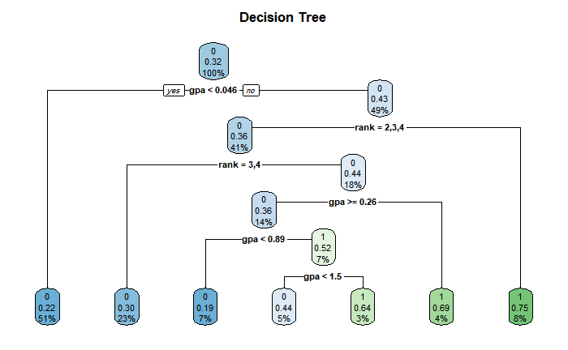

```r
# plot the result
rpart.plot(tree_model, main="Decision Tree")
```

```r
#summary of the tree
summary(tree_model)
```

```
Call:
rpart(formula = admit ~ gpa + rank, data = norm_data, method = "class")
  n= 395

          CP nsplit rel error    xerror       xstd
1 0.06349206      0 1.0000000 1.0000000 0.07351777
2 0.02380952      2 0.8730159 0.9206349 0.07183929
3 0.01190476      4 0.8253968 0.9285714 0.07201886
4 0.01000000      6 0.8015873 0.9444444 0.07237006

Variable importance
 gpa rank
  60   40

Node number 1: 395 observations,    complexity param=0.06349206
  predicted class=0  expected loss=0.3189873  P(node) =1
    class counts:   269   126
   probabilities: 0.681 0.319
  left son=2 (203 obs) right son=3 (192 obs)
  Primary splits:
      gpa  < 0.04603463 to the left,  improve=8.730748, (0 missing)
      rank splits as  RRLL, improve=7.110760, (0 missing)
  Surrogate splits:
      rank splits as  RLRL, agree=0.539, adj=0.052, (0 split)

Node number 2: 203 observations
  predicted class=0  expected loss=0.2167488  P(node) =0.5139241
    class counts:   159    44
   probabilities: 0.783 0.217

Node number 3: 192 observations,    complexity param=0.06349206
  predicted class=0  expected loss=0.4270833  P(node) =0.4860759
    class counts:   110    82
   probabilities: 0.573 0.427
  left son=6 (160 obs) right son=7 (32 obs)
  Primary splits:
      rank splits as  RLLL, improve=8.0083330, (0 missing)
      gpa  < 1.458101   to the left,  improve=0.5037879, (0 missing)

Node number 6: 160 observations,    complexity param=0.02380952
```

[output cut: 48 more lines]

```
    class counts:    14    15
   probabilities: 0.483 0.517
  left son=106 (18 obs) right son=107 (11 obs)
  Primary splits:
      gpa < 1.458101   to the left,  improve=0.5029606, (0 missing)

Node number 106: 18 observations
  predicted class=0  expected loss=0.4444444  P(node) =0.04556962
    class counts:    10     8
   probabilities: 0.556 0.444

Node number 107: 11 observations
  predicted class=1  expected loss=0.3636364  P(node) =0.0278481
    class counts:     4     7
   probabilities: 0.364 0.636
```

```r
#test data through the model
result <- predict(tree_model,norm_data,type="class")
result
```

```
  1   2   3   4   5   6   7   8   9  10  11  12  13  14  15  16  17  18  19  20  21
  0   0   1   0   0   0   0   0   0   0   0   0   1   0   1   0   0   0   0   1   0
 22  23  24  25  26  27  28  29  30  31  32  33  34  35  36  37  38  39  40  41  42
  0   0   0   0   1   1   0   0   0   0   0   0   0   0   0   0   0   0   0   0   0
 43  44  45  46  47  48  49  50  51  52  53  54  55  56  57  58  59  60  61  62  63
  0   0   0   0   1   0   0   0   0   0   0   0   0   0   0   0   0   0   0   0   0
 64  65  66  67  68  69  70  71  73  74  75  76  77  78  79  80  81  82  83  84  85
  0   0   0   0   0   1   1   0   0   1   0   0   0   0   0   1   0   0   0   0   0
 86  87  88  89  90  91  92  93  94  95  96  97  98  99 100 101 102 103 104 105 106
  0   0   1   0   1   0   1   0   0   1   0   0   0   0   0   0   0   0   0   1   0
107 108 109 110 111 112 113 114 115 116 117 118 119 120 121 122 123 124 125 126 127
  1   0   0   1   0   0   0   0   0   0   1   0   1   0   0   0   0   0   0   0   1
128 129 130 131 132 133 134 135 136 137 138 139 140 141 142 143 144 145 146 147 148
  0   0   0   0   0   0   0   0   0   0   0   0   1   0   0   0   0   0   0   0   0
149 150 151 152 153 154 155 156 157 158 159 160 161 162 163 164 165 166 167 168 169
```

[output cut: 24 more lines]

```r
# accuracy
confusionMatrix <- table(Actual_Value=norm_data$admit,Predicted_Value=result)
confusionMatrix
```

```
            Predicted_Value
Actual_Value   0   1
           0 252  17
           1  84  42
```

```r
#Accuracy of 74%
##(confusionMatrix[[1,1]] + confusionMatrix[[2,2]]) / sum(confusionMatrix)
sum(diag(confusionMatrix))/sum(confusionMatrix)
```

```
[1] 0.7443038
```

the decision tree shows the best accuracy of 74%, therefore its the chosen model to predict admission.